# Determining Optimal Simulation Repetition for Forest Stand Modeling: A Replication Analysis of the ForCEEPS Forest Growth Model

Clémentine de Montgolfier

2025-09-09

# Abstract

Forest growth modeling is essential for sustainable forest management and climate change mitigation strategies. However, determining the optimal number of simulation repetitions required to achieve statistically reliable estimates is challenge in computational forest ecology. This study addresses this question for the ForCEEPS forest growth model using data from the Retz forest in France.

We conducted a comprehensive replication analysis using 5,000 individual ForCEEPS simulations to determine the minimum number of simulations (n) required for stable estimates of key forest metrics including basal area, volume, biomass, productivity, and mortality. Our methodology employed a two-stage approach: first, we assessed the convergence of the coefficient of variation (CV) across different numbers ForCEEPS dynamics (m); second, we analyzed how CV and standardized error decrease with increasing simulation numbers (n).

Results demonstrate that 10 repetitions (m = 10) are sufficient for coefficient of variation convergence across all tested forest metrics. For simulation numbers, our analysis reveals that 10 simulations (n = 10) provide adequate precision for most forest management applications. While 50 simulations offer superior precision, the marginal improvement does not justify the increased computational cost for our applications.

# Introduction

## Study Objectives

This study aims to establish the minimum number of simulations for the ForCEEPS forest model in order to make conclusions that are not dependant on the stochasticity of the model. In order to do that we are going to calculate the divergence between dynamics. A dynamic being the mean of n simulation repetitions. But for this we also need to know between how many dynamics the coefficient of variation is stable. So we are going to determine :

1. **Number of(m)**: Number of dynamics between which the coefficient of variation needs to be calculated.
2. **Simulation (n)**: How many individual simulations are needed to achieve acceptable precision in forest metric estimates?

## Study Site and Model Description

### Study Area

The analysis focuses on the Retz forest (patch RETZ_00137_02). See RETZ inventory csv for more details.

### ForCEEPS Model

ForCEEPS is a spatially explicit, individual-based forest model that simulates tree growth, competition, mortality, and regeneration processes. The model operates at the individual tree level and incorporates climate variables, soil characteristics, and species-specific physiological parameters. Some output variables include:

- Total basal area (m2/ha)
- Total volume (m3/ha)
- Total biomass (t/ha)
- Annual productivity (m2/ha/year)
- Tree mortality (individuals/ha/year)

# Methods

## Simulation Framework

### Data Generation

We conducted 5,000 independent ForCEEPS simulations for the Retz forest patch, each spanning 80 years (2020-2100) with annual time steps. All simulations used identical initial forest conditions but different random seeds to capture stochastic variability in growth processes. The simulation protocol included:

- **Patch area**: 1,000 hectares
- **Simulation period**: 80 years (2020-2100)
- **Climate scenario**: Current climate conditions (retz_act.climate)
- **Management scenario**: 80_3_1_25_FSyl-80 (no management)
- **Species composition**: 9 potential species based on local forest inventory data

## Statistical Metrics

### Coefficient of Variation (CV)

The coefficient of variation was calculated as:

$$CV = \frac{\sigma}{\mu}$$

where sigma is the standard deviation and mu is the mean of the forest metric across repetitions.

### Standardized Error

The standardized error was calculated as:

$$SE = \frac{1.833 \times
\sigma}{\sqrt{n}}$$

where 1.833 represents the 90% confidence interval multiplier for a t-distribution, sigma is the standard deviation, and n is the number of simulations.

### Convergence Criteria

We used the following convergence criteria: - **Error thresholds**: Standardized error < 5% and < 10% of mean values

# Results

## Repetition Optimization Analysis (Stage 1)

The first stage of our analysis focused on determining the minimum number of dynamics (m) required for stable coefficient of variation estimates. We tested for 3 different dynamics (dynamics which are the mean of n = 2, 10, 50 forceeps simulations) for three key forest metrics.

### Analytical Approach

For each combination of simulation number (n) and repetition number (m), we:

1. Randomly sampled n simulations from our 5,000-simulation pool
2. Calculated mean values for each forest metric on the n simulations to get one dynamic
3. Repeated this process m times to generate m dynamics
4. Computed the coefficient of variation across these m dynamics
5. Assessed CV stability as m increased

### Results for Total Basal Area

#### N= 2 dynamics

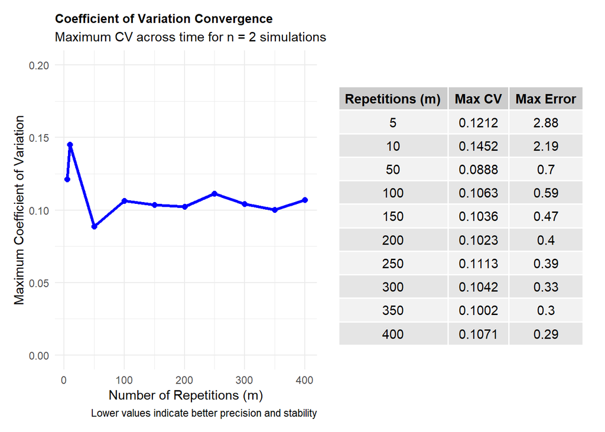

Coefficient of variation analysis for total basal area with 2 simulations per dynamic. The left panel shows variation coefficient evolution accross dynamic numbers. The right panel demonstrates CV and errors as table.

#### N= 10 dynamics

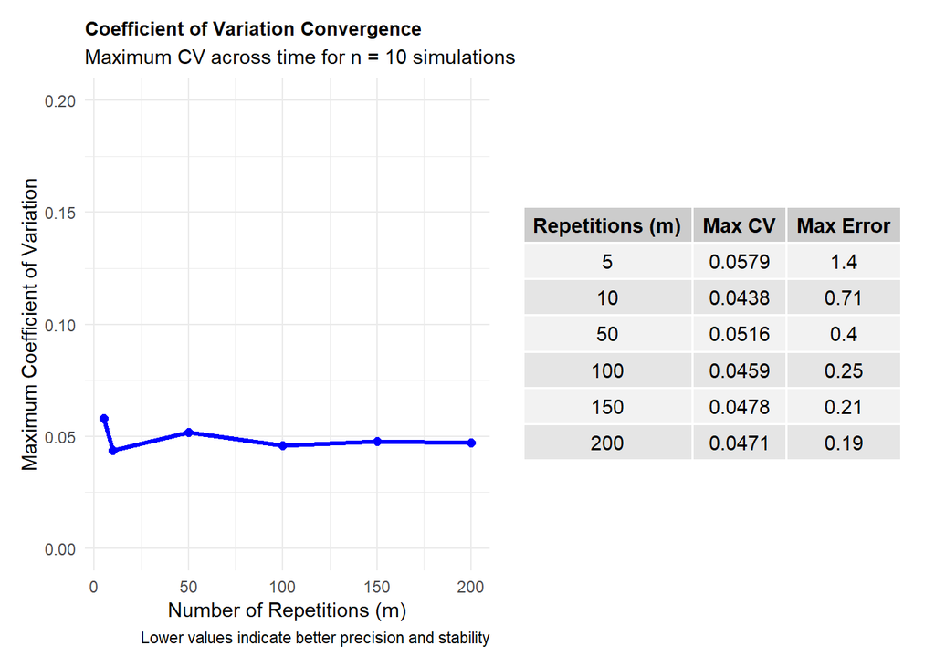

Coefficient of variation analysis for total basal area with 10 simulations per dynamic. CV values stabilize around 0.05 with good convergence achieved at 10 dynamics, representing an optimal balance between precision and computational efficiency.

**Analysis**: With 10 simulations per dynamic, the coefficient of variation decreases substantially to approximately 0.05 and achieves stable convergence at just 5-10 dynamics. The standard error reduces to 1 m2/ha, representing a significant improvement in precision.

#### N= 50 dynamics

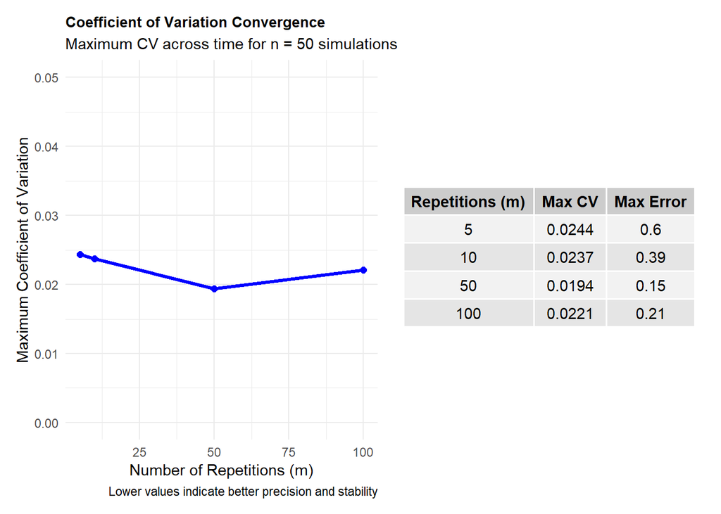

Coefficient of variation analysis for total basal area with 50 simulations per dynamic. CV values are very low (approximately 0.02) and demonstrate excellent stability from the first dynamic group, indicating high precision with minimal uncertainty.

**Analysis**: With 50 simulations per dynamic, the coefficient of variation is extremely low (approximately 0.02) and achieves immediate stability from the first dynamic group.

### Results for Total Volume

#### N= 2 dynamics

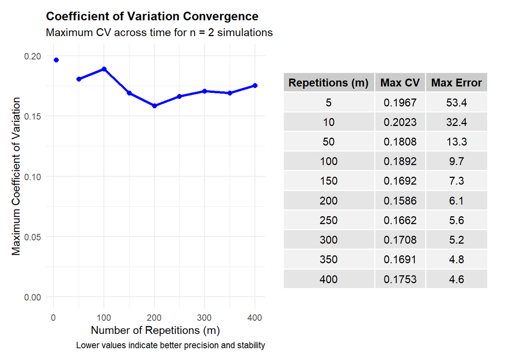

Coefficient of variation analysis for total volume with 2 simulations per dynamic. Similar patterns to basal area are observed, with CV values requiring substantial dynamics for convergence.

#### N= 10 dynamics

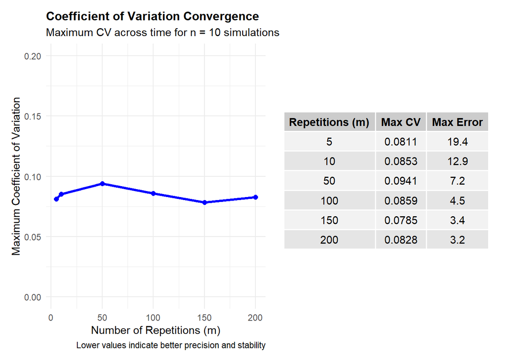

Coefficient of variation analysis for total volume with 10 simulations per dynamic. Convergence patterns mirror those observed for basal area, confirming the robustness of our findings across forest metrics.

### Results for Total Biomass

#### N= 2 dynamics

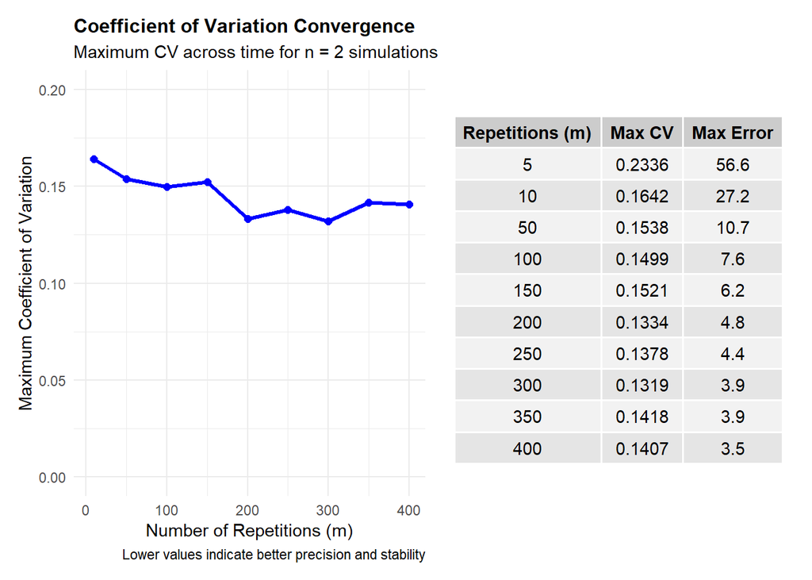

Coefficient of variation analysis for total biomass with 2 simulations per dynamic. Biomass estimates show similar convergence patterns to other forest metrics, validating our methodological approach.

**Analysis**: Biomass estimates with 2 simulations per dynamic demonstrate similar high variability patterns as observed for basal area and volume, requiring substantial dynamics for convergence.

#### N= 10 dynamics

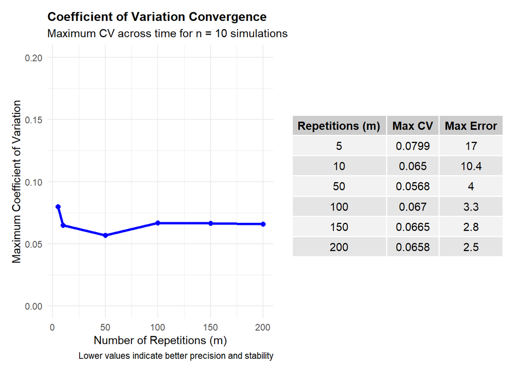

Coefficient of variation analysis for total biomass with 10 simulations per dynamic. Results consistently support the conclusion that 10 dynamics provide adequate convergence for forest modeling applications.

**Analysis**: Biomass estimates with 10 simulations per dynamic consistently demonstrate optimal convergence behavior, supporting the general conclusion that 10 dynamics provide adequate precision for forest modeling applications. I skipped the 50 simulations analysis for biomass as the patterns are consistent with previous metrics.

### Stage 1 Conclusions

The analysis demonstrates that while 50 simulations provide superior precision from the outset, 10 repetitions achieve acceptable precision when using the mean of at least 10 simulations, establishing our framework for Stage 2 analysis.

## Simulation Optimization Analysis (Stage 2)

Having established that 10 repetitions provide optimal convergence (m = 10), we now focus on determining the minimum number of simulations (n) required to achieve acceptable precision levels. This analysis examines how coefficient of variation and standardized error decrease as simulation numbers increase from 1 to 150.

### Analytical Framework

Using m = 10 repetitions, we tested simulation group sizes ranging from 1 to 150 simulations. For each simulation group size, we:

1. Generated 10 independent repetitions, each containing n simulations
2. Calculated mean forest metrics for each repetition
3. Computed coefficient of variation and standardized error across repetitions
4. Assessed precision improvement with increasing simulation numbers

### Results for Total Basal Area

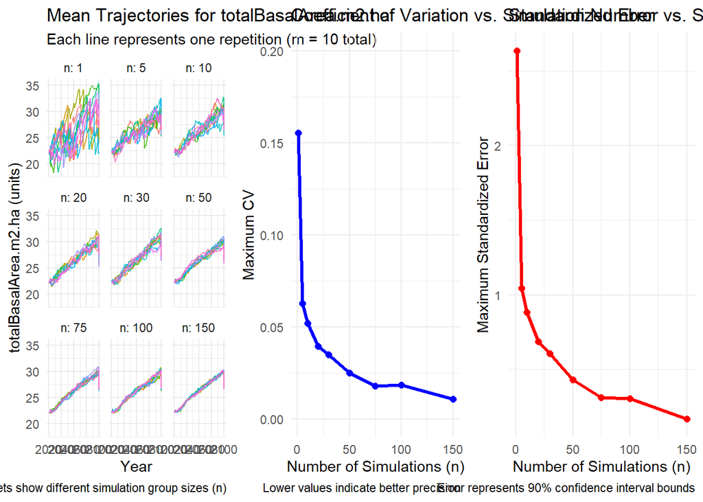

Simulation optimization analysis for total basal area. Left panel shows mean trajectories across different simulation group sizes. Center panel demonstrates CV reduction with increasing simulation numbers. Right panel shows standardized error convergence, with significant improvements observed up to n=20.

**Analysis**: Basal area estimates show rapid precision improvement up to n=10-20 simulations, with diminishing returns beyond n=50. The standardized error decreases substantially from n=1 to n=20, with minimal additional improvement at higher simulation numbers.

### Results for Total Volume

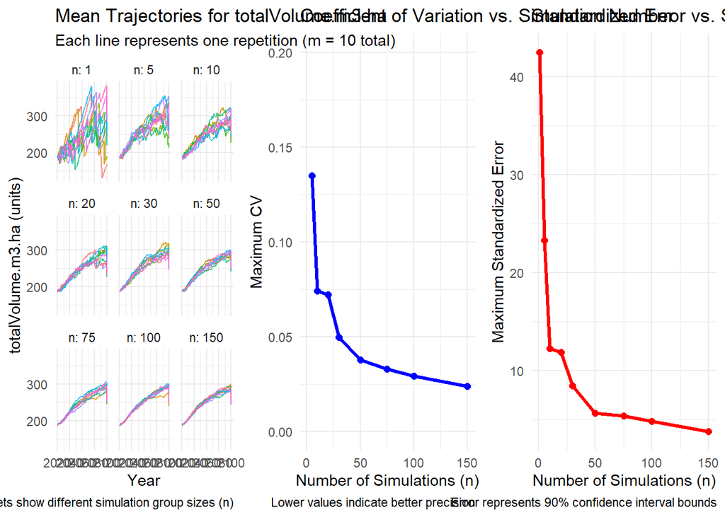

Simulation optimization analysis for total volume. Volume estimates show similar convergence patterns to basal area, with optimal precision achieved around n=10-20 simulations.

**Analysis**: Volume metrics demonstrate consistent convergence patterns with basal area estimates, confirming the robustness of our simulation optimization approach across different forest metrics.

### Results for Total Biomass

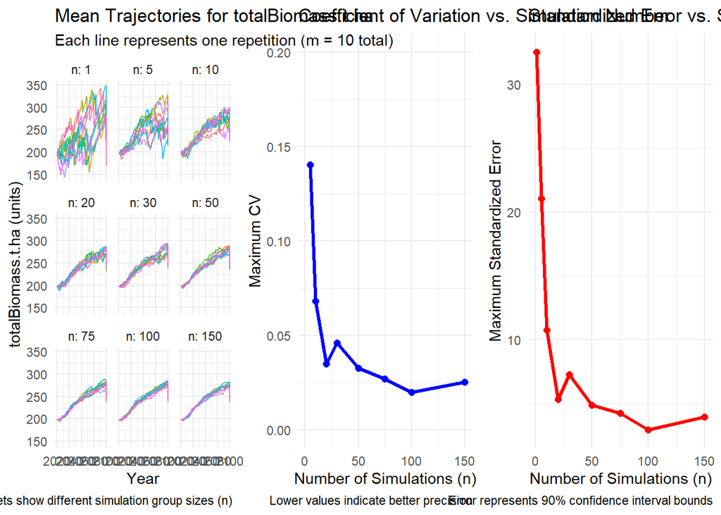

Simulation optimization analysis for total biomass. Biomass estimates demonstrate consistent convergence behavior, supporting the robustness of our optimization approach across multiple forest metrics.

**Analysis**: Biomass estimates demonstrate consistent convergence behavior across all simulation numbers, further validating the robustness of our optimization approach across multiple forest metrics.

## Analysis of Productivity Metrics

Working on productivity analysis to: - Obtain more temporally stable values (less variation, making error less date-dependent) - Reduce dependence on initial values (strong divergence in early years affects other accumulated metrics)

### Species-Level Productivity Analysis

### Species-Level Results

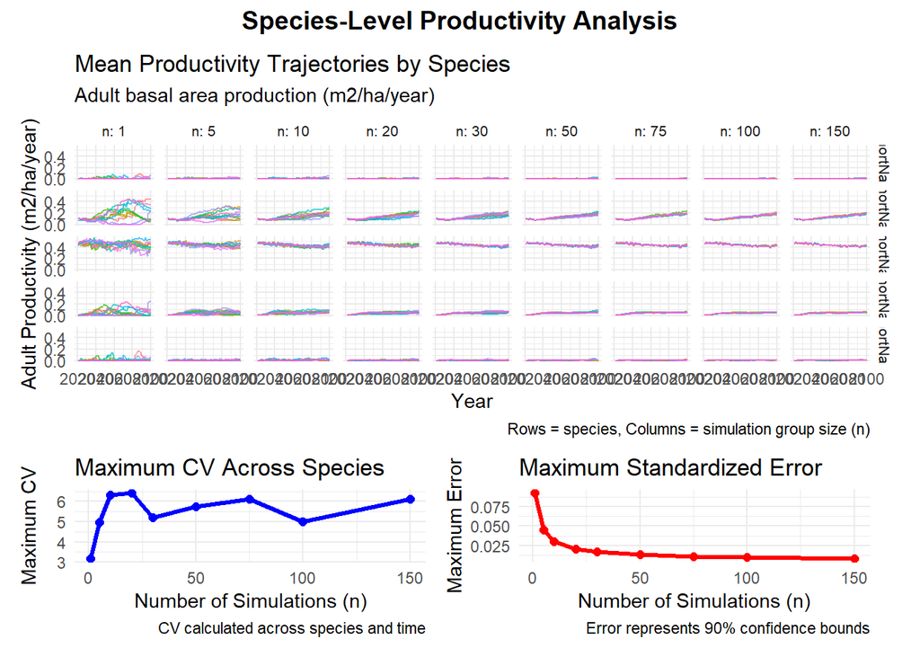

Species-level productivity analysis showing coefficient of variation and error patterns across different simulation group sizes for individual tree species.

**Species-Level Analysis Notes**: Coefficient of variation is unreliable for some species because certain values are zero (making the mean null and CV infinite). Additionally, some species have very low productivity, resulting in very high coefficient of variation values.

### Total Productivity Analysis

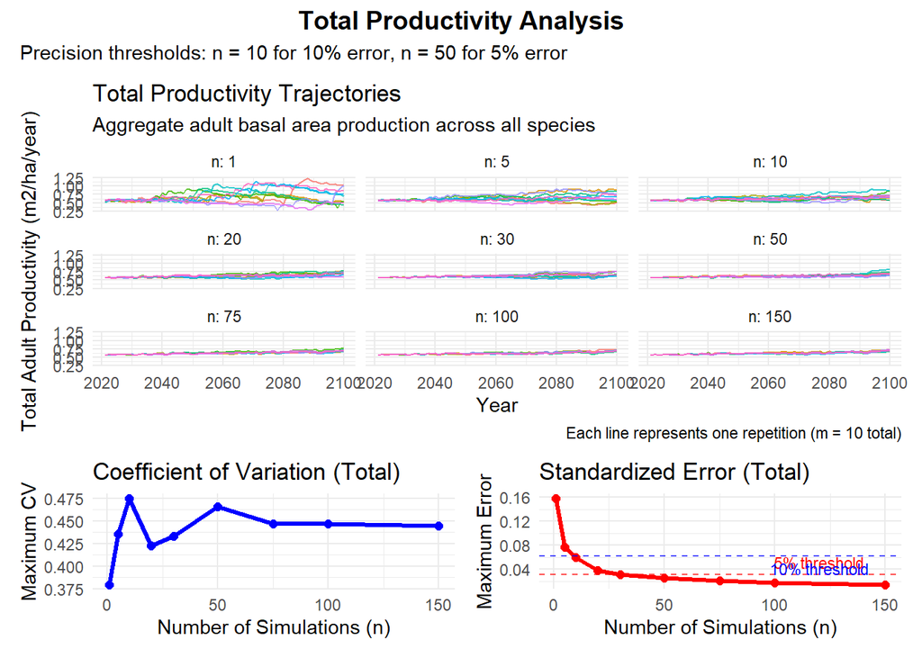

Total productivity analysis across all species, showing convergence patterns for aggregated productivity metrics with precision thresholds at 5% and 10% error levels.

**Threshold Analysis Results**: - For 5% error threshold: **50 simulations** required  
- For 10% error threshold: **10 simulations** required

### Mortality Analysis

Analyzing tree mortality (deadNumber_ha) from the productivity scene dataset.

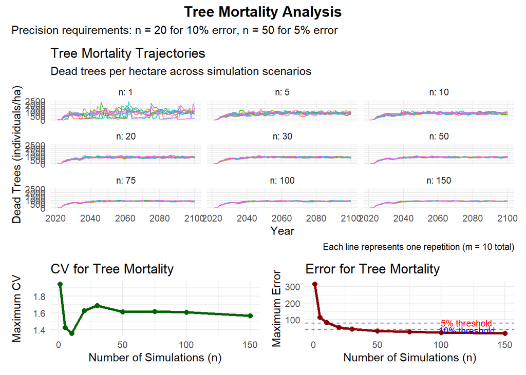

Tree mortality analysis showing the number of simulations required to achieve stable estimates of forest mortality rates with defined precision thresholds.

**Mortality Analysis Results**: - n = **10** for 10.5% error - n = **20** for 10% error  
- n = **50** for 5% error

# Discussion

## Methodological Considerations

### Strengths

1. **Comprehensive scope**: Analysis covered multiple forest metrics across 80-year simulations
2. **Large sample size**: 5,000 independent simulations provide robust statistical foundation
3. **Systematic approach**: Two-stage optimization ensures both repetition and simulation parameters are optimized
4. **Practical focus**: Results directly applicable to operational forest modeling

### Limitations

1. **Single forest type**: Results based solely on one initial inventory (to test on different inventories would be a good idea)
2. **Fixed time horizon**: 80-year simulation period may not capture long-term dynamics
3. **Limited climate scenarios**: Analysis used current climate conditions only
4. **Management regime**: Analyses were done with no management.

## Other way of determination, discarded

Before this analyses we conducted an other one. We discarded this approach because we decided on using a more robust method with variation coefficient and more independency between groups of repetitions. Howevec I keep this one in the document for the sake of transparency, and in order to understand our process and choices.

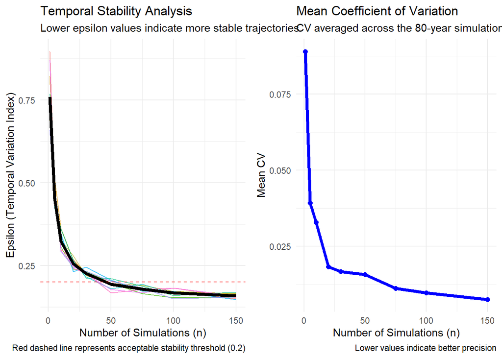